# Exploratory Data Analysis

Mangaraj & Saha

## Introduction

Exploratory Data Analysis and the Data preprocessing phases are important phases in a data science project.

During the exploratory data analysis phase, we check the data as a whole and try to understand it at an abstract level. We also look for irregularities within the data and plan for the data preprocessing phase.

The Data proprocessing phase is very important in the sequence of phases. Often we do not have full control over collection of data and the data that is given to us has irregularities such as missing values, is out of range or is not in the proper format fit for further processing. These are just a few examples of irregularities that can be found in the dataset.

During the data preprocessing phase, we take care of such irregularities and make the data fit for further processing and analysis.

## Exploring the dataset

In this section, we would discuss the following:

- what we are exploring in the data set.
- what preprocessing steps we are doing.

### Initial state.

Initially, the SHIP dataset had the following number of rows and columns.

```
## [1] 4308  400
```

### Removal of unlabelled data.

```
## [1] 886 400
```

This is the distribution of Liver_fat over the labelled data:

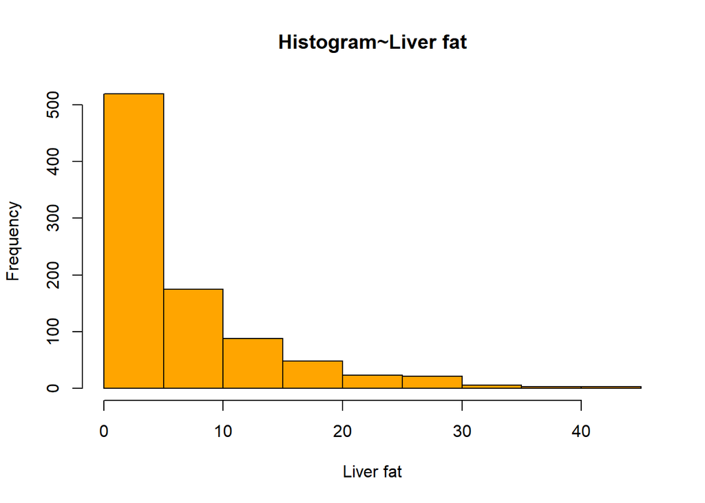

Box Plot of age of the correspondents:

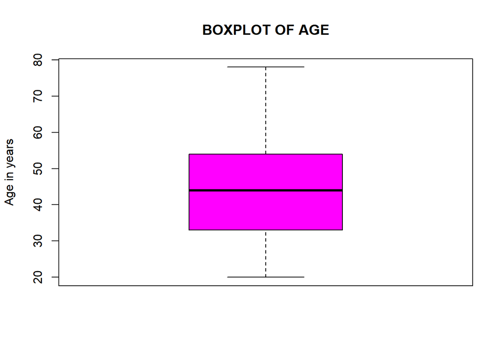

**Note:** In our further analysis, we would convert the Liver_fat to a categorical value. Anything above 10 would be denoted as “1” or positive cases, while the rest would be “0” or negative cases.

### Removal of unrelated columns

8 columns were removed because they logically do not contribute to the target variable. After this operation, there would be 392 columns.

```
## [1] 886 392
```

### Handling Missing Values

In the initial dataset, there would always be irregularities, one of the major being missing values. There might be a considerable amount of data missing in particular columns or in specific rows.

The below chart shows the columns which has missing data in the labelled dataset.

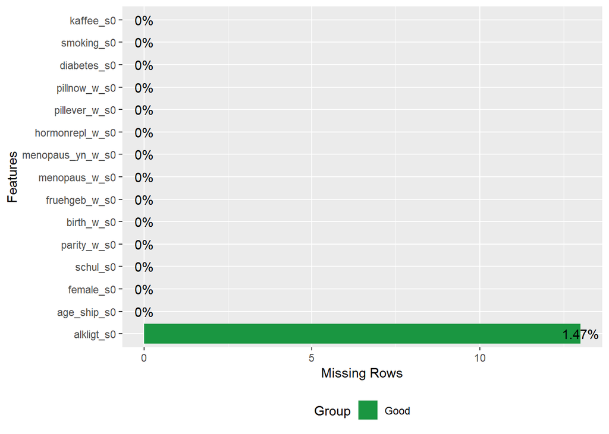

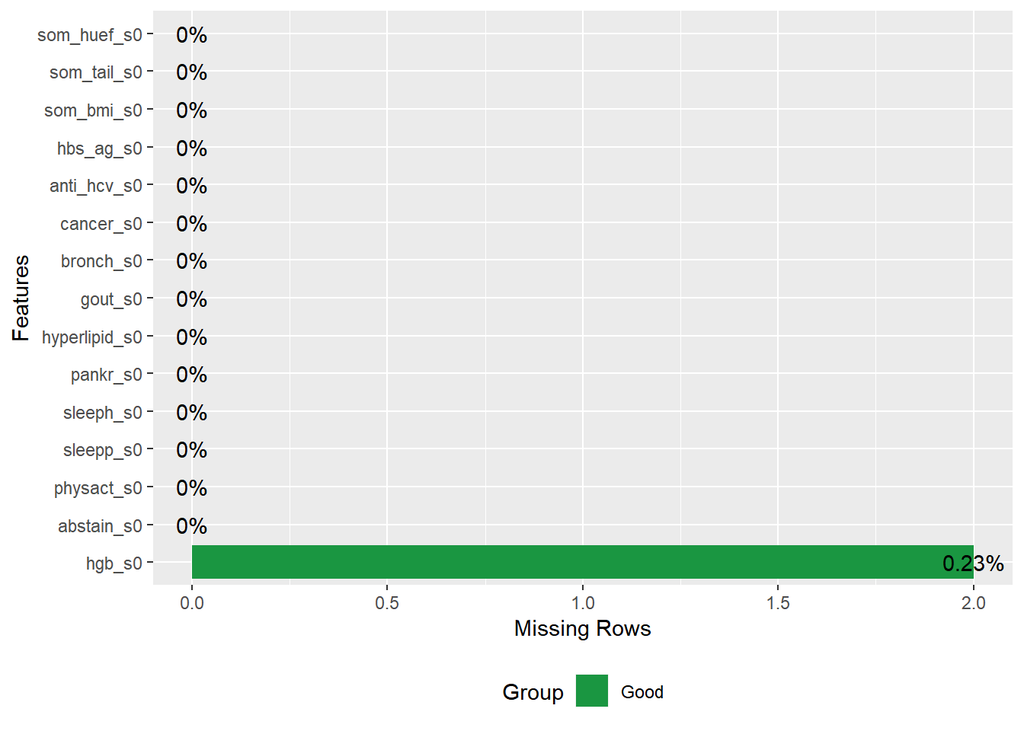

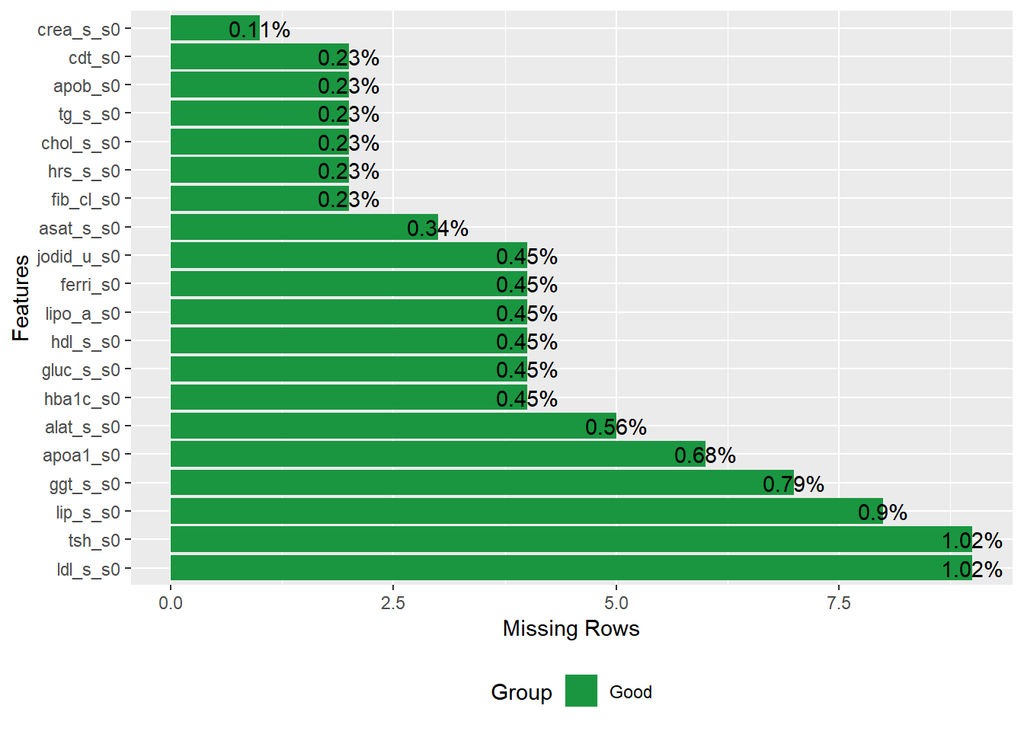

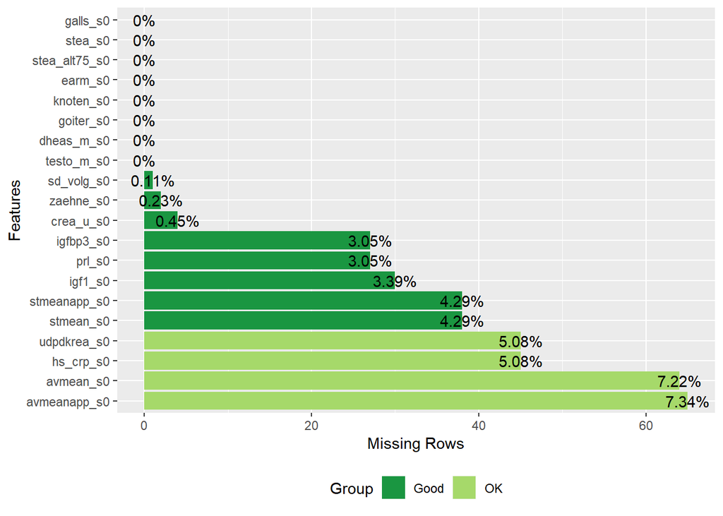

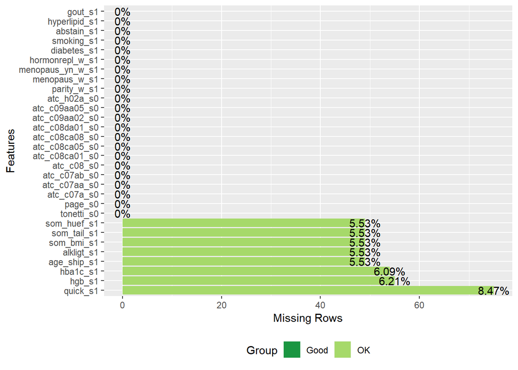

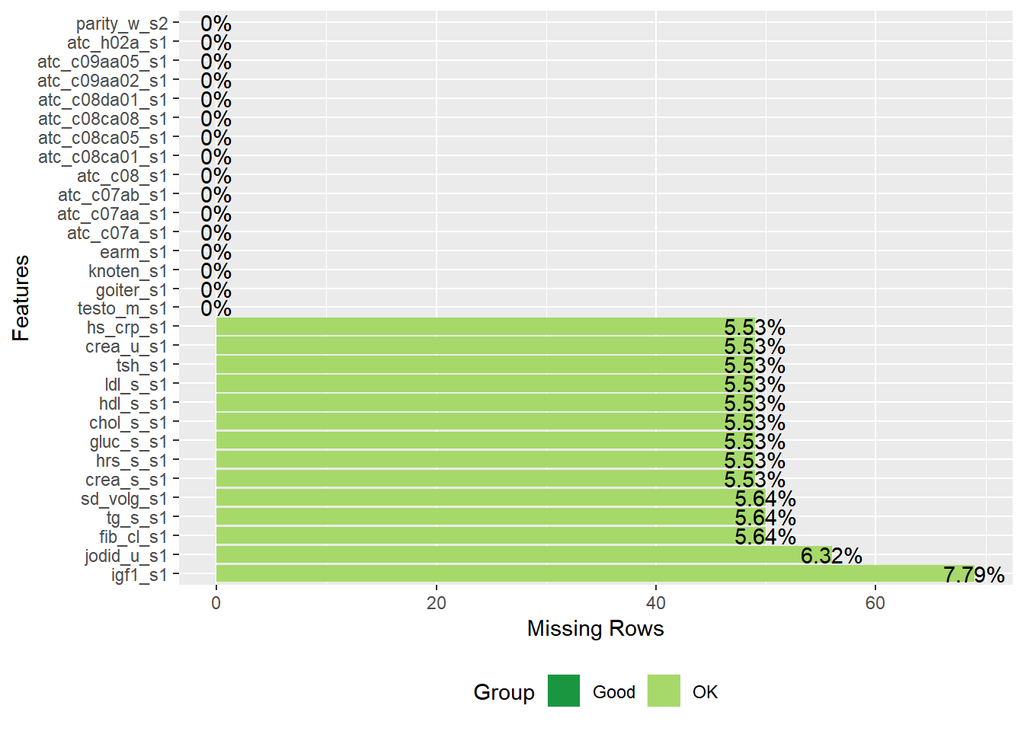

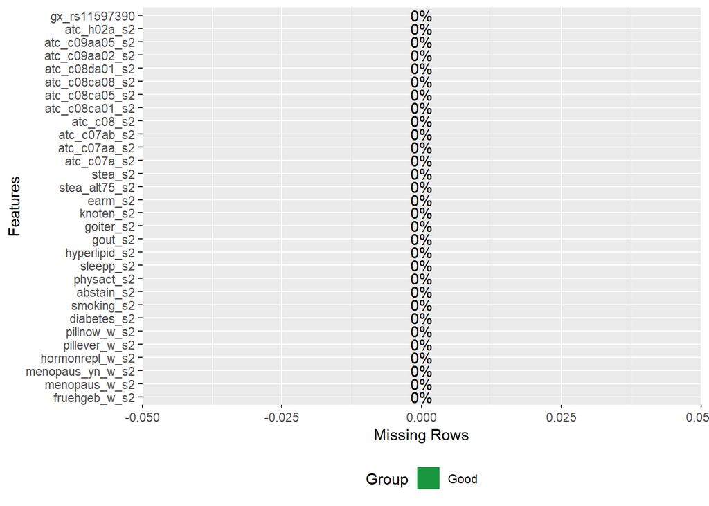

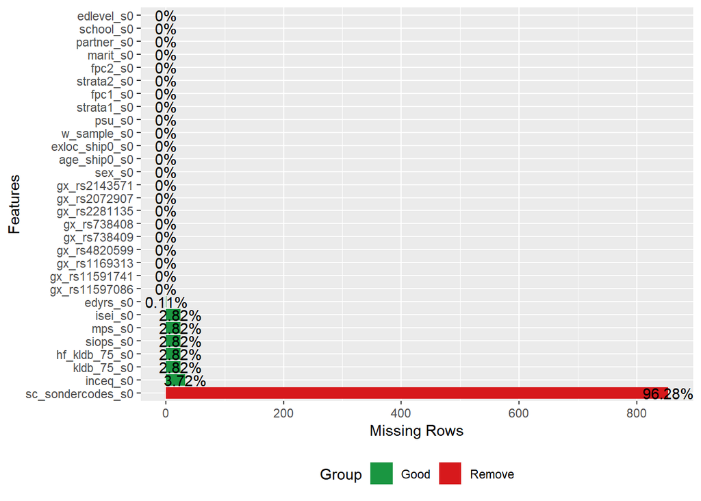

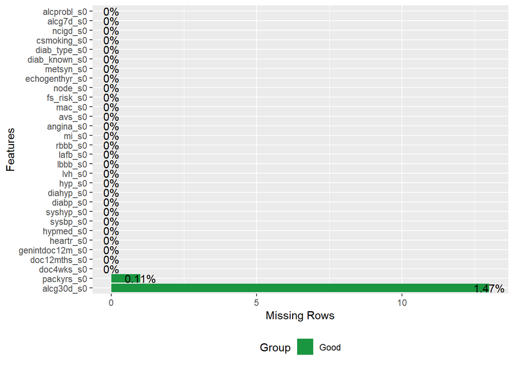

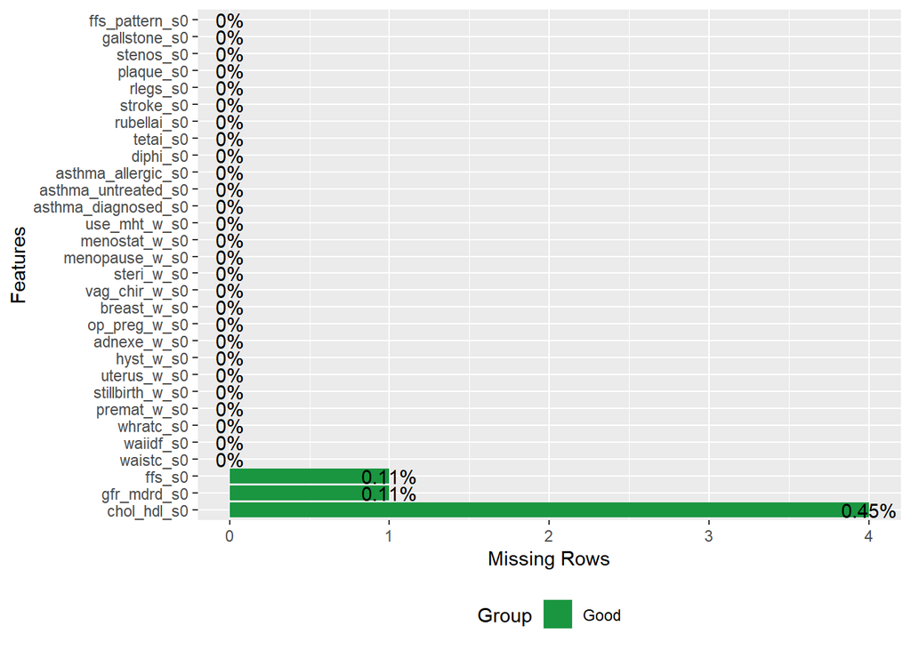

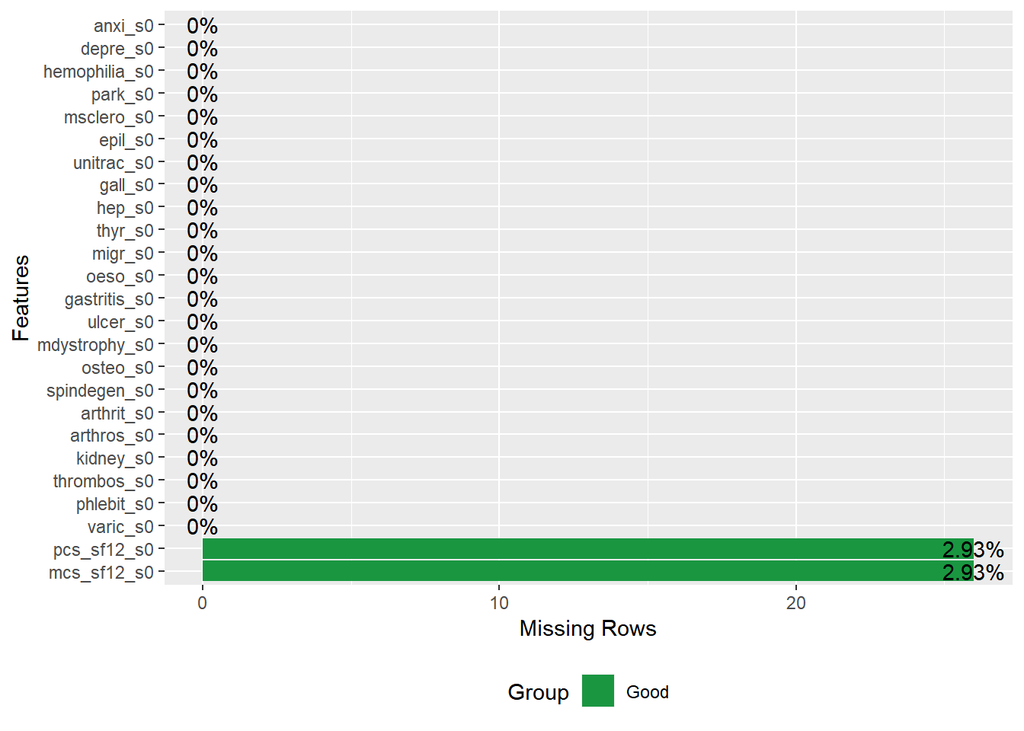

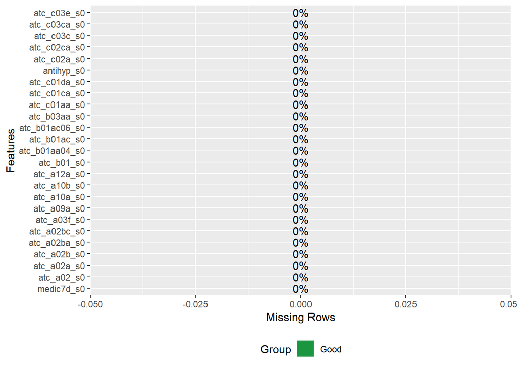

[1 more figures not shown]

##### Factor Datatypes

If the missing value is of Factor datatype and

- signifies gender, then we put a new category (value) instead of missing value.
- does not signify gender, then we put “None” in place of missing value.

##### Numerical Datatype

If the missing value is numeric, and

- signifies gender, then we convert it to categorical (value) and insert a new category.
- does not signify gender then we do further analysis.

### MICE Imputation.

We use the MICE package to impute the missing values of numerical type.

### Boruta (Feature Selection)

```
## [1] "The relevance curve"
```

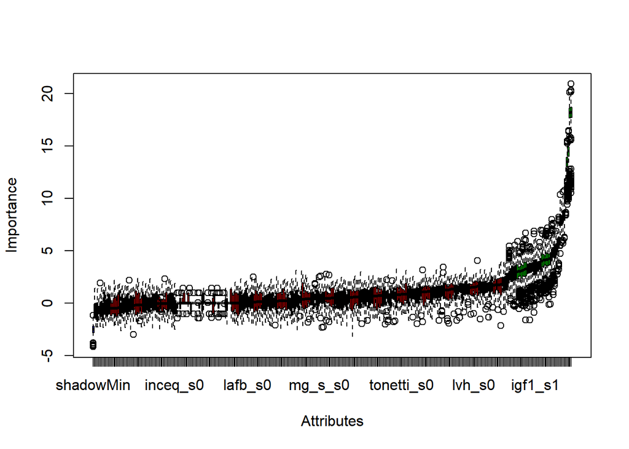

```
## [1] "Plot showing attribute importance over analysis time."
```

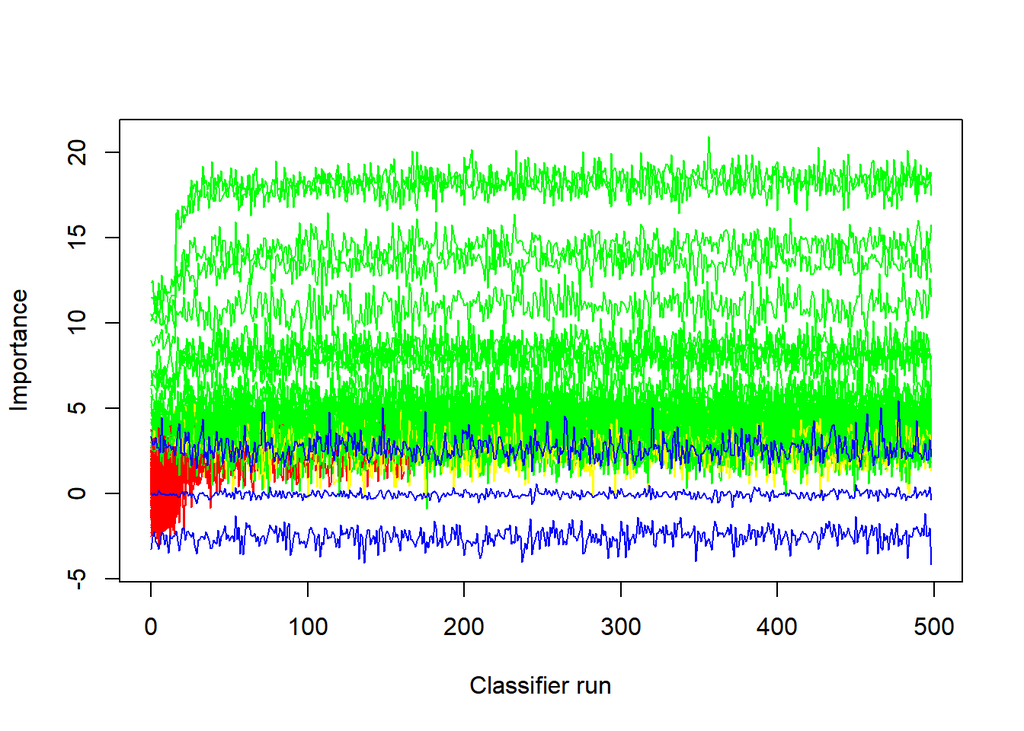

```
## [1] "List of relevant columns:"
```

```
## Boruta performed 499 iterations in 11.83786 mins.
## Tentatives roughfixed over the last 499 iterations.
##  45 attributes confirmed important: abstain_s2, age_ship_s0,
## age_ship_s1, age_ship0_s0, alat_s_s0 and 40 more;
##  300 attributes confirmed unimportant: abstain_s0, abstain_s1,
## adnexe_w_s0, alcg7d_s0, alcprobl_s0 and 295 more;
```